# **Exercices !**

- Display a choropleth map with Boys/girls total births disparity
- The same but weighted by total dpt population
- Display a choropleth map with number of girls named Emma born in 2018
- The same but weighted by total dpt population ( for instance nb of Emma births per thousand of population in the dpt OR use dpt population [...])

to do this you must find a file with 2018 population for every dpt. the file must contain a department column with the same data as the prenoms dpt column...

SUPERBONUS

- choropleth map for the most innovant departements , population weighted what is innovation ?
- choropleth map for the most trendsetting departements , population weighted what is trendsetting ? we could detect firstname that appear (or come again..) in one or a few departments only, and then grows in other departments.

Intro

```python
!pip install geopandas
import geopandas as gpd
import matplotlib.pyplot as plt
%matplotlib inline
!pip install descartes
import descartes
import pandas as pd
```

```
     |████████████████████████████████| 972kB 2.7MB/s
     |████████████████████████████████| 14.8MB 320kB/s
     |████████████████████████████████| 6.5MB 46.3MB/s
```

```python
from google.colab import drive
drive.mount('/content/drive')
```

```python
path_shp = "/content/drive/My Drive/A5/Python for data analysis/TD3/departements/departements-20140306-50m.shp"
map_df = gpd.read_file(path_shp)
map_df.head()
```

|  | code_insee | nom | nuts3 | wikipedia | geometry |
| --- | --- | --- | --- | --- | --- |
| 0 | 01 | Ain | FR711 | b'fr:Ain (d\xe9partement)' | POLYGON ((5.25559 45.78459, 5.23987 45.77758, ... |
| 1 | 02 | Aisne | FR221 | b'fr:Aisne (d\xe9partement)' | POLYGON ((3.48175 48.86640, 3.48647 48.85768, ... |
| 2 | 03 | Allier | FR721 | b'fr:Allier (d\xe9partement)' | POLYGON ((2.38613 46.33196, 2.38407 46.33112, ... |
| 3 | 04 | Alpes-de-Haute-Provence | FR821 | fr:Alpes-de-Haute-Provence | POLYGON ((6.66579 43.83120, 6.67673 43.83178, ... |
| 4 | 05 | Hautes-Alpes | FR822 | fr:Hautes-Alpes | POLYGON ((6.24158 44.44686, 6.24411 44.44693, ... |

```python
map_df =map_df[map_df.code_insee.str.contains("\d\d\d")== False]
#On a enlever les DOM TOM et maintenant on voit mieux !
```

```python
# Je veux le merger avec Dataframe valeur a afficher sur carte
path_csv = "/content/drive/My Drive/A5/Python for data analysis/TD3/dpt_2019/dpt2019.csv"
prenoms = pd.read_csv(path_csv, sep=";")
prenoms
```

|  | sexe | preusuel | annais | dpt | nombre |
| --- | --- | --- | --- | --- | --- |
| 0 | 1 | _PRENOMS_RARES | 1900 | 02 | 7 |
| 1 | 1 | _PRENOMS_RARES | 1900 | 04 | 9 |
| 2 | 1 | _PRENOMS_RARES | 1900 | 05 | 8 |
| 3 | 1 | _PRENOMS_RARES | 1900 | 06 | 23 |
| 4 | 1 | _PRENOMS_RARES | 1900 | 07 | 9 |
| ... | ... | ... | ... | ... | ... |
| 3676677 | 2 | ZYA | 2018 | 59 | 3 |
| 3676678 | 2 | ZYA | XXXX | XX | 252 |
| 3676679 | 2 | ZYNA | 2013 | 93 | 3 |
| 3676680 | 2 | ZYNA | XXXX | XX | 54 |
| 3676681 | 2 | ZYNEB | XXXX | XX | 111 |

3676682 rows × 5 columns

- Display a choropleth map with Boys/girls total births disparity

```python
pr_gb=prenoms.groupby(["dpt", "sexe"]).nombre.sum()
pr_gb
```

```
dpt  sexe
01   1        223592
     2        216540
02   1        430054
     2        415771
03   1        254648
              ...
973  2         79971
974  1        617721
     2        583845
XX   1       3779609
     2       4685897
Name: nombre, Length: 200, dtype: int64
```

```python
pr_gb = pr_gb.unstack()
pr_gb
```

| sexe dpt | 1 | 2 |
| --- | --- | --- |
| 01 | 223592 | 216540 |
| 02 | 430054 | 415771 |
| 03 | 254648 | 245510 |
| 04 | 55387 | 50633 |
| 05 | 65511 | 61180 |
| ... | ... | ... |
| 971 | 339474 | 303637 |
| 972 | 334396 | 305431 |
| 973 | 94663 | 79971 |
| 974 | 617721 | 583845 |
| XX | 3779609 | 4685897 |

100 rows × 2 columns

```python
pr_gb["ratio (type 1)"] = pr_gb[1]/pr_gb[2]
pr_gb
```

| sexe dpt | 1 | 2 | ratio (type 1) |
| --- | --- | --- | --- |
| 01 | 223592 | 216540 | 1.032567 |
| 02 | 430054 | 415771 | 1.034353 |
| 03 | 254648 | 245510 | 1.037220 |
| 04 | 55387 | 50633 | 1.093891 |
| 05 | 65511 | 61180 | 1.070791 |
| ... | ... | ... | ... |
| 971 | 339474 | 303637 | 1.118026 |
| 972 | 334396 | 305431 | 1.094833 |
| 973 | 94663 | 79971 | 1.183717 |
| 974 | 617721 | 583845 | 1.058022 |
| XX | 3779609 | 4685897 | 0.806592 |

100 rows × 3 columns

```python
pr_gb["code_insee"]=pr_gb.index
# Merge
merged = map_df.merge(pr_gb,on="code_insee")
merged.head()
```

|  | code_insee | nom | nuts3 | wikipedia | geometry | 1 | 2 | ratio (type 1) |
| --- | --- | --- | --- | --- | --- | --- | --- | --- |
| 0 | 01 | Ain | FR711 | b'fr:Ain (d\xe9partement)' | POLYGON ((5.25559 45.78459, 5.23987 45.77758, ... | 223592 | 216540 | 1.032567 |
| 1 | 02 | Aisne | FR221 | b'fr:Aisne (d\xe9partement)' | POLYGON ((3.48175 48.86640, 3.48647 48.85768, ... | 430054 | 415771 | 1.034353 |
| 2 | 03 | Allier | FR721 | b'fr:Allier (d\xe9partement)' | POLYGON ((2.38613 46.33196, 2.38407 46.33112, ... | 254648 | 245510 | 1.037220 |
| 3 | 04 | Alpes-de-Haute-Provence | FR821 | fr:Alpes-de-Haute-Provence | POLYGON ((6.66579 43.83120, 6.67673 43.83178, ... | 55387 | 50633 | 1.093891 |
| 4 | 05 | Hautes-Alpes | FR822 | fr:Hautes-Alpes | POLYGON ((6.24158 44.44686, 6.24411 44.44693, ... | 65511 | 61180 | 1.070791 |

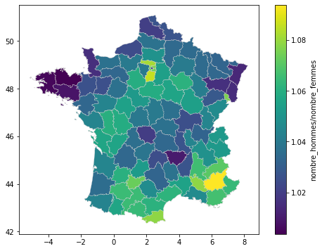

```python
fig, ax = plt.subplots(1, figsize=(8, 6))

merged.plot(column="ratio (type 1)",   ax=ax, linewidth=0.3,edgecolor="0.8",legend=True,legend_kwds
            ={"label": "nombre_hommes/nombre_femmes"})
```

- The same but weighted by total dpt population

```python
pr_gb=prenoms.groupby(["dpt", "sexe"]).nombre.sum()
pr_gb = pr_gb.unstack()
pr_gb["ratio (type 1)"] = pr_gb[1]/(pr_gb[1]+pr_gb[2])
pr_gb
```

| sexe dpt | 1 | 2 | ratio (type 1) |
| --- | --- | --- | --- |
| 01 | 223592 | 216540 | 0.508011 |
| 02 | 430054 | 415771 | 0.508443 |
| 03 | 254648 | 245510 | 0.509135 |
| 04 | 55387 | 50633 | 0.522420 |
| 05 | 65511 | 61180 | 0.517093 |
| ... | ... | ... | ... |
| 971 | 339474 | 303637 | 0.527862 |
| 972 | 334396 | 305431 | 0.522635 |
| 973 | 94663 | 79971 | 0.542065 |
| 974 | 617721 | 583845 | 0.514097 |
| XX | 3779609 | 4685897 | 0.446472 |

100 rows × 3 columns

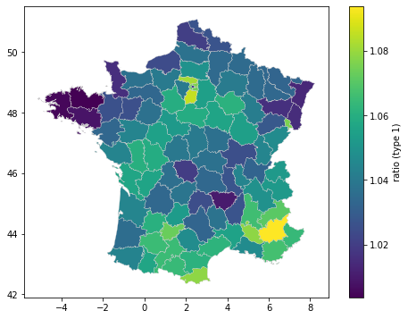

```python
fig, ax = plt.subplots(1, figsize=(8, 6))

merged.plot(column="ratio (type 1)",   ax=ax, linewidth=0.3,edgecolor="0.8",legend=True,legend_kwds
            ={"label": "ratio (type 1)"})
```

```python
pr_gb["code_insee"]=pr_gb.index
# Merge
merged = map_df.merge(pr_gb,on="code_insee")
merged.head()
```

|  | code_insee | nom | nuts3 | wikipedia | geometry | 1 | 2 | ratio (type 1) |
| --- | --- | --- | --- | --- | --- | --- | --- | --- |
| 0 | 01 | Ain | FR711 | b'fr:Ain (d\xe9partement)' | POLYGON ((5.25559 45.78459, 5.23987 45.77758, ... | 223592 | 216540 | 0.508011 |
| 1 | 02 | Aisne | FR221 | b'fr:Aisne (d\xe9partement)' | POLYGON ((3.48175 48.86640, 3.48647 48.85768, ... | 430054 | 415771 | 0.508443 |
| 2 | 03 | Allier | FR721 | b'fr:Allier (d\xe9partement)' | POLYGON ((2.38613 46.33196, 2.38407 46.33112, ... | 254648 | 245510 | 0.509135 |
| 3 | 04 | Alpes-de-Haute-Provence | FR821 | fr:Alpes-de-Haute-Provence | POLYGON ((6.66579 43.83120, 6.67673 43.83178, ... | 55387 | 50633 | 0.522420 |
| 4 | 05 | Hautes-Alpes | FR822 | fr:Hautes-Alpes | POLYGON ((6.24158 44.44686, 6.24411 44.44693, ... | 65511 | 61180 | 0.517093 |

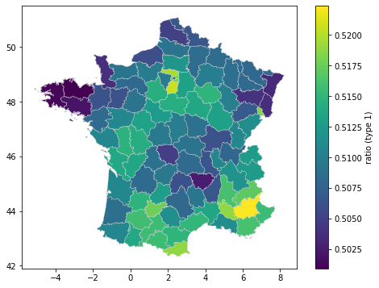

```python
fig, ax = plt.subplots(1, figsize=(8, 6))

merged.plot(column="ratio (type 1)",   ax=ax, linewidth=0.3,edgecolor="0.8",legend=True,legend_kwds
            ={"label": "ratio (type 1)"})
```

- Display a choropleth map with number of girls named Emma born in 2018

```python
prenoms
```

|  | sexe | preusuel | annais | dpt | nombre |
| --- | --- | --- | --- | --- | --- |
| 0 | 1 | _PRENOMS_RARES | 1900 | 02 | 7 |
| 1 | 1 | _PRENOMS_RARES | 1900 | 04 | 9 |
| 2 | 1 | _PRENOMS_RARES | 1900 | 05 | 8 |
| 3 | 1 | _PRENOMS_RARES | 1900 | 06 | 23 |
| 4 | 1 | _PRENOMS_RARES | 1900 | 07 | 9 |
| ... | ... | ... | ... | ... | ... |
| 3676677 | 2 | ZYA | 2018 | 59 | 3 |
| 3676678 | 2 | ZYA | XXXX | XX | 252 |
| 3676679 | 2 | ZYNA | 2013 | 93 | 3 |
| 3676680 | 2 | ZYNA | XXXX | XX | 54 |
| 3676681 | 2 | ZYNEB | XXXX | XX | 111 |

3676682 rows × 5 columns

```python
emma_df = prenoms[(prenoms.preusuel=="EMMA")&(prenoms.annais=="2018")]
emma_df
```

|  | sexe | preusuel | annais | dpt | nombre |
| --- | --- | --- | --- | --- | --- |
| 2343695 | 2 | EMMA | 2018 | 01 | 37 |
| 2343696 | 2 | EMMA | 2018 | 02 | 38 |
| 2343697 | 2 | EMMA | 2018 | 03 | 28 |
| 2343698 | 2 | EMMA | 2018 | 04 | 6 |
| 2343699 | 2 | EMMA | 2018 | 05 | 10 |
| ... | ... | ... | ... | ... | ... |
| 2343788 | 2 | EMMA | 2018 | 95 | 79 |
| 2343789 | 2 | EMMA | 2018 | 971 | 17 |
| 2343790 | 2 | EMMA | 2018 | 972 | 11 |
| 2343791 | 2 | EMMA | 2018 | 973 | 11 |
| 2343792 | 2 | EMMA | 2018 | 974 | 43 |

98 rows × 5 columns

```python
#departements manquants car pas d'EMMA nés dans les departements correspondants à cette date
dpts_pr = list(emma_df.dpt)
dpts_map = list(map_df.code_insee)

print([dpt for dpt in dpts_map if dpt not in dpts_pr])
```

```
['2A', '2B', '46']
```

On a pas besoin des données pour les départements corses 2A & 2B car on souhaite seulement afficher la carte de la métropole, par contre il manque la ligne correspondante au département 46

```python
emma_df = emma_df.append({'dpt':'46', 'nombre':0}, ignore_index=True)
```

```python
emma_df=emma_df.groupby(["dpt"]).nombre.sum()
emma_df
```

```
dpt
01     37
02     38
03     28
04      6
05     10
       ..
95     79
971    17
972    11
973    11
974    43
Name: nombre, Length: 99, dtype: int64
```

```python
print(emma_df)
```

```
dpt
01     37
02     38
03     28
04      6
05     10
       ..
95     79
971    17
972    11
973    11
974    43
Name: nombre, Length: 99, dtype: int64
```

```python
emma_df = emma_df.to_frame()
emma_df["code_insee"]=emma_df.index
# Merge
merged = map_df.merge(emma_df,on="code_insee")
merged.head()
```

|  | code_insee | nom | nuts3 | wikipedia | geometry | nombre |
| --- | --- | --- | --- | --- | --- | --- |
| 0 | 01 | Ain | FR711 | b'fr:Ain (d\xe9partement)' | POLYGON ((5.25559 45.78459, 5.23987 45.77758, ... | 37 |
| 1 | 02 | Aisne | FR221 | b'fr:Aisne (d\xe9partement)' | POLYGON ((3.48175 48.86640, 3.48647 48.85768, ... | 38 |
| 2 | 03 | Allier | FR721 | b'fr:Allier (d\xe9partement)' | POLYGON ((2.38613 46.33196, 2.38407 46.33112, ... | 28 |
| 3 | 04 | Alpes-de-Haute-Provence | FR821 | fr:Alpes-de-Haute-Provence | POLYGON ((6.66579 43.83120, 6.67673 43.83178, ... | 6 |
| 4 | 05 | Hautes-Alpes | FR822 | fr:Hautes-Alpes | POLYGON ((6.24158 44.44686, 6.24411 44.44693, ... | 10 |

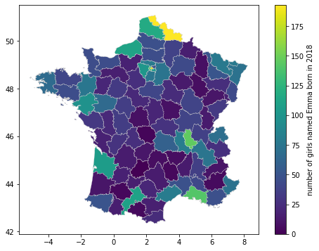

```python
import matplotlib.pyplot as plt
fig, ax = plt.subplots(1, figsize=(8, 6))

merged.plot(column="nombre",   ax=ax, linewidth=0.3,edgecolor="0.8",legend=True,legend_kwds
            ={"label": "number of girls named Emma born in 2018"})
```

```python
tl_preusuel = prenoms[prenoms.annais=="2018"]
tl_preusuel_sr = tl_preusuel.groupby(["dpt"]).nombre.sum()
tl_preusuel_sr = tl_preusuel_sr.rename('nombre tout prenom confondu')
tl_preusuel_sr
```

```
dpt
01      2493
02      3289
03      1825
04       370
05       592
       ...
95     15164
971     2543
972     2187
973     5618
974    10437
Name: nombre tout prenom confondu, Length: 99, dtype: int64
```

```python
emma_sr = emma_df.nombre
emma_sr = emma_sr.rename('nombre d\'Emma')
emma_sr
```

```
dpt
01     37
02     38
03     28
04      6
05     10
       ..
95     79
971    17
972    11
973    11
974    43
Name: nombre d'Emma, Length: 99, dtype: int64
```

```python
emma_and_all_preusuels = pd.concat([emma_sr, tl_preusuel_sr], axis=1)
emma_and_all_preusuels['ratio d\'Emma'] = emma_and_all_preusuels['nombre d\'Emma'] / emma_and_all_preusuels['nombre tout prenom confondu']
emma_and_all_preusuels
```

| dpt | nombre d'Emma | nombre tout prenom confondu | ratio d'Emma |
| --- | --- | --- | --- |
| 01 | 37 | 2493 | 0.014842 |
| 02 | 38 | 3289 | 0.011554 |
| 03 | 28 | 1825 | 0.015342 |
| 04 | 6 | 370 | 0.016216 |
| 05 | 10 | 592 | 0.016892 |
| ... | ... | ... | ... |
| 95 | 79 | 15164 | 0.005210 |
| 971 | 17 | 2543 | 0.006685 |
| 972 | 11 | 2187 | 0.005030 |
| 973 | 11 | 5618 | 0.001958 |
| 974 | 43 | 10437 | 0.004120 |

99 rows × 3 columns

```python
emma_and_all_preusuels["code_insee"]=emma_df.index
# Merge
merged = map_df.merge(emma_and_all_preusuels,on="code_insee")
```

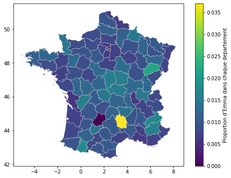

```python
import matplotlib.pyplot as plt
fig, ax = plt.subplots(1, figsize=(8, 6))

merged.plot(column='ratio d\'Emma',   ax=ax, linewidth=0.3,edgecolor="0.8",legend=True,legend_kwds
            ={"label": "Proportion d'Emma dans chaque departement"})
```

SUPERBONUS

- choropleth map for the most innovant departements , population weighted what is innovation ?

Negligons les genres, et l'augmentation de la population au cours du temps

```python
pr_no_sexe = prenoms.drop(columns='sexe')
pr_no_sexe.groupby(['dpt', 'annais', 'preusuel']).sum()
```

| dpt | annais | preusuel | nombre |
| --- | --- | --- | --- |
| 01 | 1900 | ADRIEN | 8 |
|  |  | ADRIENNE | 9 |
|  |  | ADÈLE | 5 |
|  |  | AIME | 10 |
|  |  | AIMÉE | 7 |
| ... | ... | ... | ... |
| XX | XXXX | ÖMER | 267 |
|  |  | ÖZGE | 30 |
|  |  | ÖZGÜR | 24 |
|  |  | ÖZKAN | 24 |
|  |  | ÖZLEM | 99 |

3633780 rows × 1 columns

```python
table = pd.pivot_table(pr_no_sexe, values='nombre', index=['dpt', 'annais'],
                    columns=['preusuel'])
```

```python
table
```

| dpt | preusuel annais | A | AADAM | AADEL | AADIL | AAHIL | AAKASH | AALIA | AALIYA | AALIYAH | AALYA | AALYAH | AANOR | AARICIA | AARON | AARONE | AARONN | AAROUN | AARUSH | AAYA | AAYAN | AAZIZ | AB | AB-DEL | ABA | ABABACAR | ABAKAR | ABANE | ABAS | … |
| --- | --- | --- | --- | --- | --- | --- | --- | --- | --- | --- | --- | --- | --- | --- | --- | --- | --- | --- | --- | --- | --- | --- | --- | --- | --- | --- | --- | --- | --- | --- |
| 01 | 1900 | NaN | NaN | NaN | NaN | NaN | NaN | NaN | NaN | NaN | NaN | NaN | NaN | NaN | NaN | NaN | NaN | NaN | NaN | NaN | NaN | NaN | NaN | NaN | NaN | NaN | NaN | NaN | NaN | … |
|  | 1901 | NaN | NaN | NaN | NaN | NaN | NaN | NaN | NaN | NaN | NaN | NaN | NaN | NaN | NaN | NaN | NaN | NaN | NaN | NaN | NaN | NaN | NaN | NaN | NaN | NaN | NaN | NaN | NaN | … |
|  | 1902 | NaN | NaN | NaN | NaN | NaN | NaN | NaN | NaN | NaN | NaN | NaN | NaN | NaN | NaN | NaN | NaN | NaN | NaN | NaN | NaN | NaN | NaN | NaN | NaN | NaN | NaN | NaN | NaN | … |
|  | 1903 | NaN | NaN | NaN | NaN | NaN | NaN | NaN | NaN | NaN | NaN | NaN | NaN | NaN | NaN | NaN | NaN | NaN | NaN | NaN | NaN | NaN | NaN | NaN | NaN | NaN | NaN | NaN | NaN | … |
|  | 1904 | NaN | NaN | NaN | NaN | NaN | NaN | NaN | NaN | NaN | NaN | NaN | NaN | NaN | NaN | NaN | NaN | NaN | NaN | NaN | NaN | NaN | NaN | NaN | NaN | NaN | NaN | NaN | NaN | … |
| ... | ... | ... | ... | ... | ... | ... | ... | ... | ... | ... | ... | ... | ... | ... | ... | ... | ... | ... | ... | ... | ... | ... | ... | ... | ... | ... | ... | ... | ... | … |
| 974 | 2016 | NaN | NaN | NaN | NaN | NaN | NaN | NaN | NaN | 8.0 | NaN | NaN | NaN | NaN | 50.0 | NaN | NaN | NaN | NaN | NaN | NaN | NaN | NaN | NaN | NaN | NaN | NaN | NaN | NaN | … |
|  | 2017 | NaN | NaN | NaN | NaN | NaN | NaN | NaN | NaN | 4.0 | NaN | NaN | NaN | NaN | 71.0 | NaN | NaN | NaN | NaN | NaN | NaN | NaN | NaN | NaN | NaN | NaN | NaN | NaN | NaN | … |
|  | 2018 | NaN | NaN | NaN | NaN | NaN | NaN | NaN | NaN | 10.0 | NaN | NaN | NaN | NaN | 49.0 | NaN | NaN | NaN | NaN | NaN | NaN | NaN | NaN | NaN | NaN | NaN | NaN | NaN | NaN | … |
|  | 2019 | NaN | NaN | NaN | NaN | NaN | NaN | NaN | NaN | 4.0 | NaN | NaN | NaN | NaN | 67.0 | NaN | NaN | NaN | NaN | NaN | NaN | NaN | NaN | NaN | NaN | NaN | NaN | NaN | NaN | … |
| XX | XXXX | 27.0 | 27.0 | 56.0 | 178.0 | 18.0 | 26.0 | 41.0 | 205.0 | 831.0 | 122.0 | 210.0 | 41.0 | 40.0 | 447.0 | 156.0 | 89.0 | 42.0 | 25.0 | 50.0 | 70.0 | 30.0 | 73.0 | 42.0 | 20.0 | 62.0 | 31.0 | 20.0 | 44.0 | … |

11541 rows × 34263 columns

```python
table = table.fillna(0)
```

```python
table.values.shape
```

```
(11541, 34263)
```

```python
table["array"] = list(table.values)
```

```python
df = table["array"]
df
```

```
dpt  annais
01   1900      [0.0, 0.0, 0.0, 0.0, 0.0, 0.0, 0.0, 0.0, 0.0, ...
     1901      [0.0, 0.0, 0.0, 0.0, 0.0, 0.0, 0.0, 0.0, 0.0, ...
     1902      [0.0, 0.0, 0.0, 0.0, 0.0, 0.0, 0.0, 0.0, 0.0, ...
     1903      [0.0, 0.0, 0.0, 0.0, 0.0, 0.0, 0.0, 0.0, 0.0, ...
     1904      [0.0, 0.0, 0.0, 0.0, 0.0, 0.0, 0.0, 0.0, 0.0, ...
                                     ...
974  2016      [0.0, 0.0, 0.0, 0.0, 0.0, 0.0, 0.0, 0.0, 8.0, ...
     2017      [0.0, 0.0, 0.0, 0.0, 0.0, 0.0, 0.0, 0.0, 4.0, ...
     2018      [0.0, 0.0, 0.0, 0.0, 0.0, 0.0, 0.0, 0.0, 10.0,...
     2019      [0.0, 0.0, 0.0, 0.0, 0.0, 0.0, 0.0, 0.0, 4.0, ...
XX   XXXX      [27.0, 27.0, 56.0, 178.0, 18.0, 26.0, 41.0, 20...
Name: array, Length: 11541, dtype: object
```

```python
import numpy as np
df = df.apply(lambda x:x/np.amax(x))
```

```python
df
```

```
dpt  annais
01   1900      [0.0, 0.0, 0.0, 0.0, 0.0, 0.0, 0.0, 0.0, 0.0, ...
     1901      [0.0, 0.0, 0.0, 0.0, 0.0, 0.0, 0.0, 0.0, 0.0, ...
     1902      [0.0, 0.0, 0.0, 0.0, 0.0, 0.0, 0.0, 0.0, 0.0, ...
     1903      [0.0, 0.0, 0.0, 0.0, 0.0, 0.0, 0.0, 0.0, 0.0, ...
     1904      [0.0, 0.0, 0.0, 0.0, 0.0, 0.0, 0.0, 0.0, 0.0, ...
                                     ...
974  2016      [0.0, 0.0, 0.0, 0.0, 0.0, 0.0, 0.0, 0.0, 0.007...
     2017      [0.0, 0.0, 0.0, 0.0, 0.0, 0.0, 0.0, 0.0, 0.003...
     2018      [0.0, 0.0, 0.0, 0.0, 0.0, 0.0, 0.0, 0.0, 0.008...
     2019      [0.0, 0.0, 0.0, 0.0, 0.0, 0.0, 0.0, 0.0, 0.003...
XX   XXXX      [0.004810261892036344, 0.004810261892036344, 0...
Name: array, Length: 11541, dtype: object
```

```python
df = df.unstack()
```

```python
df
```

[output not shown]

100 rows × 121 columns